# Práctica final AIRBNB

Antoni Sbert Cañellas

Link repositorio github: https://github.com/mangunillos/practivaAirBNB

Una vez que se han visualizado los datos del csv y vemos que tiene header, se procede a cargar estos en un dataframe de pandas para poder analizar los datos

```python
%matplotlib inline
import csv
import pandas as pd
import numpy as np
import seaborn as sns
import matplotlib.pyplot as plt
sns.set_style('darkgrid')
sns.set_context('notebook')

airbnbdata = []
with open('airbnb.csv', encoding='utf-8', newline='') as csvDataFile:
    reader = csv.reader(csvDataFile)
    for row in reader:
        airbnbdata.append(row)

df = pd.read_csv('airbnb.csv')

sns.set_style('darkgrid')
sns.set_context('notebook')
```

Mostramos la informació del dataset para ver que datos són interessantes para la solución que queremos proponer

```python
df.info()
```

```
<class 'pandas.core.frame.DataFrame'>
RangeIndex: 17608 entries, 0 to 17607
Data columns (total 74 columns):
id                                              17608 non-null int64
listing_url                                     17608 non-null object
scrape_id                                       17608 non-null int64
last_scraped                                    17608 non-null object
name                                            17607 non-null object
description                                     17393 non-null object
neighborhood_overview                           8213 non-null object
picture_url                                     17608 non-null object
host_id                                         17608 non-null int64
host_url                                        17608 non-null object
host_name                                       17606 non-null object
host_since                                      17606 non-null object
host_location                                   17572 non-null object
host_about                                      11696 non-null object
host_response_time                              15862 non-null object
host_response_rate                              15862 non-null object
host_acceptance_rate                            16098 non-null object
host_is_superhost                               17606 non-null object
host_thumbnail_url                              17606 non-null object
host_picture_url                                17606 non-null object
host_neighbourhood                              364 non-null object
host_listings_count                             17606 non-null float64
host_total_listings_count                       17606 non-null float64
host_verifications                              17608 non-null object
host_has_profile_pic                            17606 non-null object
host_identity_verified                          17606 non-null object
neighbourhood                                   8213 non-null object
neighbourhood_cleansed                          17608 non-null object
neighbourhood_group_cleansed                    0 non-null float64
latitude                                        17608 non-null float64
longitude                                       17608 non-null float64
property_type                                   17608 non-null object
room_type                                       17608 non-null object
accommodates                                    17608 non-null int64
bathrooms                                       0 non-null float64
bathrooms_text                                  17600 non-null object
bedrooms                                        17333 non-null float64
```

[output cut: 24 more lines]

```
review_scores_accuracy                          10951 non-null float64
review_scores_cleanliness                       10953 non-null float64
review_scores_checkin                           10949 non-null float64
review_scores_communication                     10951 non-null float64
review_scores_location                          10950 non-null float64
review_scores_value                             10949 non-null float64
license                                         11431 non-null object
instant_bookable                                17608 non-null object
calculated_host_listings_count                  17608 non-null int64
calculated_host_listings_count_entire_homes     17608 non-null int64
calculated_host_listings_count_private_rooms    17608 non-null int64
calculated_host_listings_count_shared_rooms     17608 non-null int64
reviews_per_month                               11173 non-null float64
dtypes: float64(19), int64(21), object(34)
memory usage: 9.9+ MB
```

A primera vista vemos que hay una gran cantidad de datos sobre las diferentes viviendas. Aún asi vemos que segurament hay algunos datos que no podremos aprovechar como por ejemplo la url de la foto.

# Seleccion de datos relevantes

Empezamos con el análisis de los datos de scraping, estos parametros una vez cogidos y visualizados de esta manera, nos encontramos que para el objetivo final, predecir el precio, no són relevantes para nosotros.

```python
df[['id', 'listing_url','scrape_id','last_scraped','name','description','neighborhood_overview','picture_url']]
```

|  | id | listing_url | scrape_id | last_scraped | name | description | neighborhood_overview | picture_url |
| --- | --- | --- | --- | --- | --- | --- | --- | --- |
| 0 | 11547 | https://www.airbnb.com/rooms/11547 | 20200919153121 | 2020-09-21 | My home at the beach | Sun, joy, relax, quality, beach & peace.<br />... | NaN | https://a0.muscache.com/pictures/494126/8c151b... |
| 1 | 100831 | https://www.airbnb.com/rooms/100831 | 20200919153121 | 2020-09-21 | HOUSE IN MALLORCA - WiFi(ET-3045) | <b>The space</b><br />House situated in a quie... | NaN | https://a0.muscache.com/pictures/675527/72b329... |
| 2 | 105891 | https://www.airbnb.com/rooms/105891 | 20200919153121 | 2020-09-20 | VILLAGE HOUSE WITH POOL: IDEAL FOR FAMILIES | The house is a street on the outskirts of the ... | The village's population does not reach two th... | https://a0.muscache.com/pictures/1036816/f36ce... |
| 3 | 106833 | https://www.airbnb.com/rooms/106833 | 20200919153121 | 2020-09-20 | Villa with a big pool in Mallorca | <b>The space</b><br />This is a restored old b... | NaN | https://a0.muscache.com/pictures/710218/98134c... |
| 4 | 130669 | https://www.airbnb.com/rooms/130669 | 20200919153121 | 2020-09-20 | Room great apartment | Located in a residential neighbourhood and 10m... | Located in the center of the city, within minu... | https://a0.muscache.com/pictures/866653/58dc48... |
| ... | ... | ... | ... | ... | ... | ... | ... | ... |
| 17603 | 45489412 | https://www.airbnb.com/rooms/45489412 | 20200919153121 | 2020-09-20 | Villa Mariona | Modern and comfortable villa for 6 people comp... | NaN | https://a0.muscache.com/pictures/105faa9b-5315... |
| 17604 | 45489550 | https://www.airbnb.com/rooms/45489550 | 20200919153121 | 2020-09-20 | Holiday Home El Clavet with Mountain View, Wi-... | Located between Pollença and Port de Pollença,... | NaN | https://a0.muscache.com/pictures/f7e347f8-894c... |
| 17605 | 45493152 | https://www.airbnb.com/rooms/45493152 | 20200919153121 | 2020-09-20 | Es Molinet Selva villa Mallorca 197 | Magnificent finca with pool, garden and great ... | NaN | https://a0.muscache.com/pictures/2473f78b-359e... |
| 17606 | 45496032 | https://www.airbnb.com/rooms/45496032 | 20200919153121 | 2020-09-21 | Hab. con terraza y baño privado,piscina compar... | NaN | Habitación doble a la entrada del puerto muy c... | https://a0.muscache.com/pictures/2dd9c712-7b01... |
| 17607 | 45499210 | https://www.airbnb.com/rooms/45499210 | 20200919153121 | 2020-09-20 | Bonita Casa Adosada con Jardín | NaN | NaN | https://a0.muscache.com/pictures/c2f63ec4-fce6... |

17608 rows × 8 columns

## Datos del host

Una vez visualizados los datos del host, nos encontramos que estos parámetros no los podemos usar tampoco ya que no nos sirve para orientar el precio de la vivienda por sus características, quizas estos datos podrían llegar a ser relevantes para otro tipo de situaciones donde cobrarian más importancia

```python
df[['host_id','host_url','host_name','host_since','host_location','host_about','host_response_time','host_response_rate', 'host_acceptance_rate','host_is_superhost','host_thumbnail_url',  'host_picture_url','host_neighbourhood', 'host_listings_count', 'host_total_listings_count','host_verifications','host_has_profile_pic', 'host_identity_verified']]
```

|  | host_id | host_url | host_name | host_since | host_location | host_about | host_response_time | host_response_rate | host_acceptance_rate | host_is_superhost | host_thumbnail_url | host_picture_url | host_neighbourhood | host_listings_count | host_total_listings_count | host_verifications | host_has_profile_pic | host_identity_verified |
| --- | --- | --- | --- | --- | --- | --- | --- | --- | --- | --- | --- | --- | --- | --- | --- | --- | --- | --- |
| 0 | 42942 | https://www.airbnb.com/users/show/42942 | Daniel | 2009-10-02 | Balearic Islands, Spain | . | within an hour | 100% | 96% | f | https://a0.muscache.com/im/users/42942/profile... | https://a0.muscache.com/im/users/42942/profile... | NaN | 0.0 | 0.0 | ['email', 'phone', 'reviews', 'jumio', 'govern... | t | t |
| 1 | 529151 | https://www.airbnb.com/users/show/529151 | Miguel | 2011-04-23 | Mallorca | Somos una pareja con los mismos gustos e inter... | NaN | NaN | 100% | f | https://a0.muscache.com/im/users/529151/profil... | https://a0.muscache.com/im/users/529151/profil... | NaN | 1.0 | 1.0 | ['email', 'phone', 'facebook', 'reviews', 'jum... | t | t |
| 2 | 549192 | https://www.airbnb.com/users/show/549192 | Bartomeu | 2011-05-01 | Ariany, Balearic Islands, Spain | Hola!. Resido en una casa de campo de un puebl... | within a few hours | 100% | 83% | t | https://a0.muscache.com/im/users/549192/profil... | https://a0.muscache.com/im/users/549192/profil... | NaN | 2.0 | 2.0 | ['email', 'phone', 'facebook', 'reviews', 'jum... | t | t |
| 3 | 551974 | https://www.airbnb.com/users/show/551974 | Xisco | 2011-05-02 | Palma de Mallorca, Balearic Islands, Spain | I'm Xisco. I love Mallorcan way of life. | within a day | 100% | NaN | f | https://a0.muscache.com/im/users/551974/profil... | https://a0.muscache.com/im/users/551974/profil... | NaN | 1.0 | 1.0 | ['email', 'phone', 'reviews', 'jumio', 'offlin... | t | t |
| 4 | 643065 | https://www.airbnb.com/users/show/643065 | Nick | 2011-05-30 | Palma de Mallorca, Balearic Islands, Spain | NaN | within a day | 100% | NaN | f | https://a0.muscache.com/im/users/643065/profil... | https://a0.muscache.com/im/users/643065/profil... | NaN | 3.0 | 3.0 | ['email', 'phone', 'reviews'] | t | f |
| ... | ... | ... | ... | ... | ... | ... | ... | ... | ... | ... | ... | ... | ... | ... | ... | ... | ... | ... |
| 17603 | 131594018 | https://www.airbnb.com/users/show/131594018 | Mallorca Holiday Properties | 2017-05-23 | Av. Príncipes de España 4A, Alcudia, 07400 Is... | Mallorca Holiday Properties está formado por u... | within an hour | 100% | 100% | f | https://a0.muscache.com/im/pictures/user/dce1d... | https://a0.muscache.com/im/pictures/user/dce1d... | NaN | 56.0 | 56.0 | ['email', 'phone', 'jumio', 'offline_governmen... | t | t |
| 17604 | 285670200 | https://www.airbnb.com/users/show/285670200 | Bookiply | 2019-08-14 | DE | Bookiply is a German agency offering vacation ... | within a few hours | 87% | 100% | f | https://a0.muscache.com/im/pictures/user/8cfab... | https://a0.muscache.com/im/pictures/user/8cfab... | NaN | 243.0 | 243.0 | ['email', 'phone', 'jumio', 'offline_governmen... | t | t |
| 17605 | 3893191 | https://www.airbnb.com/users/show/3893191 | Antoni Mallorca Charme Home Rentals | 2012-10-16 | Muro, Illes Balears, Spain | NaN | within a day | 94% | 97% | f | https://a0.muscache.com/im/pictures/user/7dca3... | https://a0.muscache.com/im/pictures/user/7dca3... | NaN | 98.0 | 98.0 | ['email', 'phone', 'reviews', 'offline_governm... | t | t |
| 17606 | 350176105 | https://www.airbnb.com/users/show/350176105 | Gabriele | 2020-06-15 | Port d'Andratx, Illes Balears, Spain | NaN | NaN | NaN | NaN | f | https://a0.muscache.com/im/pictures/user/88dc0... | https://a0.muscache.com/im/pictures/user/88dc0... | NaN | 1.0 | 1.0 | ['email', 'phone'] | t | f |
| 17607 | 67725432 | https://www.airbnb.com/users/show/67725432 | Juan | 2016-04-18 | ES | NaN | within an hour | 100% | NaN | f | https://a0.muscache.com/im/pictures/user/40053... | https://a0.muscache.com/im/pictures/user/40053... | NaN | 2.0 | 2.0 | ['email', 'phone'] | t | f |

17608 rows × 18 columns

## Datos del vecindario.

Nos encontramos con más datos que no podemos usar para indicar cual es el precio del los apartamentos de manera objetiva y no podemos aprovechar esta información para obtener los precios directamente. Además que muchos campos de las columns al ser Nan nos faltaria información

```python
df[['neighbourhood','neighbourhood_cleansed','neighbourhood_group_cleansed']]
```

|  | neighbourhood | neighbourhood_cleansed | neighbourhood_group_cleansed |
| --- | --- | --- | --- |
| 0 | NaN | Calvià | NaN |
| 1 | NaN | Santa Margalida | NaN |
| 2 | Maria de la Salut, Balearic Islands, Spain | Maria de la Salut | NaN |
| 3 | NaN | Sant Llorenç des Cardassar | NaN |
| 4 | Palma de Mallorca, PM, Spain | Palma de Mallorca | NaN |
| ... | ... | ... | ... |
| 17603 | NaN | Muro | NaN |
| 17604 | NaN | Pollença | NaN |
| 17605 | NaN | Selva | NaN |
| 17606 | Andratx, Illes Balears, Spain | Andratx | NaN |
| 17607 | NaN | Llucmajor | NaN |

17608 rows × 3 columns

## Datos sobre las características de las casas

Estos datos parece que podrían servir para definir los precios de las casas aunque por ejemplo la columna bathrooms no se pordra usar y se tendria quer modificar la de bathroom_text para poder sacar valor. En estos campos la columna amenities tiene muchas información que podría llegar a ser un mini dataset y no lo usaremos para definir el precio final

```python
df[['latitude', 'longitude', 'property_type', 'room_type', 'accommodates', 'bathrooms', 'bathrooms_text', 'bedrooms', 'beds', 'amenities', 'price']]
```

|  | latitude | longitude | property_type | room_type | accommodates | bathrooms | bathrooms_text | bedrooms | beds | amenities | price |
| --- | --- | --- | --- | --- | --- | --- | --- | --- | --- | --- | --- |
| 0 | 39.51888 | 2.48182 | Entire apartment | Entire home/apt | 2 | NaN | 1 bath | 1.0 | 1.0 | ["Oven", "Wifi", "Coffee maker", "Dishes and s... | $89.00 |
| 1 | 39.76347 | 3.16255 | Entire house | Entire home/apt | 8 | NaN | 3 baths | 4.0 | 7.0 | ["First aid kit", "Hair dryer", "Iron", "Washe... | $175.00 |
| 2 | 39.66044 | 3.07165 | Entire townhouse | Entire home/apt | 6 | NaN | 2 baths | 3.0 | 4.0 | ["Smoke alarm", "Oven", "Wifi", "Garden or bac... | $140.00 |
| 3 | 39.61600 | 3.30121 | Entire villa | Entire home/apt | 4 | NaN | 1 bath | 2.0 | 4.0 | ["Pool", "Free parking on premises", "Air cond... | $200.00 |
| 4 | 39.56478 | 2.60333 | Private room in apartment | Private room | 2 | NaN | 1 bath | 1.0 | 2.0 | ["Pool", "Washer", "Air conditioning", "Kitche... | $110.00 |
| ... | ... | ... | ... | ... | ... | ... | ... | ... | ... | ... | ... |
| 17603 | 39.76505 | 3.12689 | Entire villa | Entire home/apt | 6 | NaN | 3.5 baths | 3.0 | 4.0 | ["Oven", "Wifi", "Garden or backyard", "Coffee... | $195.00 |
| 17604 | 39.89835 | 3.03647 | Entire villa | Entire home/apt | 9 | NaN | 3 baths | 5.0 | 8.0 | ["Hair dryer", "Washer", "Free parking on prem... | $110.00 |
| 17605 | 39.75437 | 2.90504 | Entire villa | Entire home/apt | 6 | NaN | 2 baths | 3.0 | 4.0 | ["Oven", "Wifi", "Garden or backyard", "Coffee... | $179.00 |
| 17606 | 39.54550 | 2.39348 | Private room in apartment | Private room | 2 | NaN | 1 bath | 1.0 | 1.0 | ["Oven", "Bread maker", "Extra pillows and bla... | $42.00 |
| 17607 | 39.44457 | 2.75415 | Entire apartment | Entire home/apt | 6 | NaN | 2 baths | 2.0 | 4.0 | ["First aid kit", "Hair dryer", "Iron", "Washe... | $100.00 |

17608 rows × 11 columns

## Datos de las noches que se pueden reservar las casa

Estos datos no los podemos usar porque no nos indican directamente el precio según las características de las casa

```python
df[['minimum_nights', 'maximum_nights', 'minimum_minimum_nights', 'maximum_minimum_nights','minimum_maximum_nights','maximum_maximum_nights','minimum_nights_avg_ntm','maximum_nights_avg_ntm']]
```

|  | minimum_nights | maximum_nights | minimum_minimum_nights | maximum_minimum_nights | minimum_maximum_nights | maximum_maximum_nights | minimum_nights_avg_ntm | maximum_nights_avg_ntm |
| --- | --- | --- | --- | --- | --- | --- | --- | --- |
| 0 | 5 | 60 | 5 | 5 | 60 | 60 | 5.0 | 60.0 |
| 1 | 7 | 365 | 7 | 7 | 1125 | 1125 | 7.0 | 1125.0 |
| 2 | 6 | 365 | 6 | 6 | 365 | 365 | 6.0 | 365.0 |
| 3 | 5 | 365 | 5 | 5 | 365 | 365 | 5.0 | 365.0 |
| 4 | 2 | 365 | 2 | 2 | 365 | 365 | 2.0 | 365.0 |
| ... | ... | ... | ... | ... | ... | ... | ... | ... |
| 17603 | 1 | 365 | 6 | 7 | 365 | 365 | 6.4 | 365.0 |
| 17604 | 1 | 1125 | 1 | 1 | 28 | 1125 | 1.0 | 590.4 |
| 17605 | 1 | 365 | 1 | 7 | 365 | 365 | 3.3 | 365.0 |
| 17606 | 1 | 7 | 1 | 1 | 1125 | 1125 | 1.0 | 1125.0 |
| 17607 | 5 | 1120 | 5 | 5 | 1120 | 1120 | 5.0 | 1120.0 |

17608 rows × 8 columns

## Datos de la disponibilidad

Según los dias y reviews, en este caso tampoco podemos usar los datos para poder determinar el precio de los immuebles

```python
df[['has_availability',
'availability_30',
'availability_60',
'availability_90',
'availability_365',
'calendar_last_scraped',
'number_of_reviews',
'number_of_reviews_ltm',
'number_of_reviews_l30d']]
```

|  | has_availability | availability_30 | availability_60 | availability_90 | availability_365 | calendar_last_scraped | number_of_reviews | number_of_reviews_ltm | number_of_reviews_l30d |
| --- | --- | --- | --- | --- | --- | --- | --- | --- | --- |
| 0 | t | 13 | 43 | 73 | 311 | 2020-09-21 | 103 | 8 | 2 |
| 1 | t | 0 | 0 | 0 | 0 | 2020-09-21 | 30 | 13 | 0 |
| 2 | t | 23 | 53 | 83 | 325 | 2020-09-20 | 14 | 0 | 0 |
| 3 | t | 20 | 50 | 80 | 355 | 2020-09-20 | 9 | 0 | 0 |
| 4 | t | 30 | 60 | 90 | 365 | 2020-09-20 | 0 | 0 | 0 |
| ... | ... | ... | ... | ... | ... | ... | ... | ... | ... |
| 17603 | t | 10 | 40 | 70 | 303 | 2020-09-20 | 0 | 0 | 0 |
| 17604 | t | 30 | 60 | 90 | 365 | 2020-09-20 | 0 | 0 | 0 |
| 17605 | t | 20 | 20 | 20 | 113 | 2020-09-20 | 0 | 0 | 0 |
| 17606 | t | 24 | 54 | 84 | 174 | 2020-09-21 | 0 | 0 | 0 |
| 17607 | t | 30 | 60 | 90 | 365 | 2020-09-20 | 0 | 0 | 0 |

17608 rows × 9 columns

## Número de reviews

Según las reviews, no podemos estimar el precio de la vivienda estos datos podrían se mejores para poder definir si hay una mayor satisfación del cliente más que del precio de la vivienda

```python
df[['number_of_reviews_l30d',
'first_review',
'last_review',
'review_scores_rating',
'review_scores_accuracy',
'review_scores_cleanliness',
'review_scores_checkin',
'review_scores_communication',
'review_scores_location',
'review_scores_value',
'license',
'instant_bookable',
'calculated_host_listings_count',
'calculated_host_listings_count_entire_homes',
'calculated_host_listings_count_private_rooms',
'calculated_host_listings_count_shared_rooms',
'reviews_per_month']]
```

|  | number_of_reviews_l30d | first_review | last_review | review_scores_rating | review_scores_accuracy | review_scores_cleanliness | review_scores_checkin | review_scores_communication | review_scores_location | review_scores_value | license | instant_bookable | calculated_host_listings_count | calculated_host_listings_count_entire_homes | calculated_host_listings_count_private_rooms | calculated_host_listings_count_shared_rooms | reviews_per_month |
| --- | --- | --- | --- | --- | --- | --- | --- | --- | --- | --- | --- | --- | --- | --- | --- | --- | --- |
| 0 | 2 | 2011-08-23 | 2020-09-06 | 96.0 | 10.0 | 9.0 | 10.0 | 10.0 | 10.0 | 10.0 | NaN | f | 1 | 1 | 0 | 0 | 0.93 |
| 1 | 0 | 2019-01-18 | 2020-01-25 | 100.0 | 10.0 | 10.0 | 10.0 | 10.0 | 10.0 | 10.0 | ETV-3045 | t | 1 | 1 | 0 | 0 | 1.47 |
| 2 | 0 | 2012-06-19 | 2019-09-03 | 97.0 | 10.0 | 10.0 | 10.0 | 10.0 | 9.0 | 10.0 | ETV/6127 | t | 2 | 2 | 0 | 0 | 0.14 |
| 3 | 0 | 2012-06-05 | 2018-08-13 | 98.0 | 10.0 | 10.0 | 10.0 | 10.0 | 9.0 | 9.0 | ET/1961 | f | 1 | 1 | 0 | 0 | 0.09 |
| 4 | 0 | NaN | NaN | NaN | NaN | NaN | NaN | NaN | NaN | NaN | NaN | t | 2 | 0 | 2 | 0 | NaN |
| ... | ... | ... | ... | ... | ... | ... | ... | ... | ... | ... | ... | ... | ... | ... | ... | ... | ... |
| 17603 | 0 | NaN | NaN | NaN | NaN | NaN | NaN | NaN | NaN | NaN | LIZE84/2017 | t | 49 | 49 | 0 | 0 | NaN |
| 17604 | 0 | NaN | NaN | NaN | NaN | NaN | NaN | NaN | NaN | NaN | NaN | t | 90 | 90 | 0 | 0 | NaN |
| 17605 | 0 | NaN | NaN | NaN | NaN | NaN | NaN | NaN | NaN | NaN | 00551ETV | t | 133 | 133 | 0 | 0 | NaN |
| 17606 | 0 | NaN | NaN | NaN | NaN | NaN | NaN | NaN | NaN | NaN | NaN | t | 1 | 0 | 1 | 0 | NaN |
| 17607 | 0 | NaN | NaN | NaN | NaN | NaN | NaN | NaN | NaN | NaN | NaN | f | 1 | 1 | 0 | 0 | NaN |

17608 rows × 17 columns

# Datos que finalmente procesaremos

Una vez que hemos analizado los datos del dataframe nos quedamos con estas columnas.

```python
df_transform = df[['latitude', 'longitude','room_type','accommodates','bathrooms', 'bedrooms','beds','price']]
```

```python
df_transform
```

|  | latitude | longitude | room_type | accommodates | bathrooms | bedrooms | beds | price |
| --- | --- | --- | --- | --- | --- | --- | --- | --- |
| 0 | 39.51888 | 2.48182 | Entire home/apt | 2 | NaN | 1.0 | 1.0 | $89.00 |
| 1 | 39.76347 | 3.16255 | Entire home/apt | 8 | NaN | 4.0 | 7.0 | $175.00 |
| 2 | 39.66044 | 3.07165 | Entire home/apt | 6 | NaN | 3.0 | 4.0 | $140.00 |
| 3 | 39.61600 | 3.30121 | Entire home/apt | 4 | NaN | 2.0 | 4.0 | $200.00 |
| 4 | 39.56478 | 2.60333 | Private room | 2 | NaN | 1.0 | 2.0 | $110.00 |
| ... | ... | ... | ... | ... | ... | ... | ... | ... |
| 17603 | 39.76505 | 3.12689 | Entire home/apt | 6 | NaN | 3.0 | 4.0 | $195.00 |
| 17604 | 39.89835 | 3.03647 | Entire home/apt | 9 | NaN | 5.0 | 8.0 | $110.00 |
| 17605 | 39.75437 | 2.90504 | Entire home/apt | 6 | NaN | 3.0 | 4.0 | $179.00 |
| 17606 | 39.54550 | 2.39348 | Private room | 2 | NaN | 1.0 | 1.0 | $42.00 |
| 17607 | 39.44457 | 2.75415 | Entire home/apt | 6 | NaN | 2.0 | 4.0 | $100.00 |

17608 rows × 8 columns

Nos encontramos que hay unas columnas que necesitan una modificación para poder ser usadas como el roomtype y modificaremos la columna bathrroms a partir de la de texto que contiene la informción

```python
#Modificamos la columna precios para que sea float
price_columns = df.price.str.split("$", expand=True)
split_price = price_columns[1].str.split(",", expand=False)
df_transform['price'] = split_price.str.join("")
df_transform['price'] = df_transform.price.astype(float)
```

```python
#Modificamos la información de los baños para que sea númerica, tomamos una decisisión arbitraria de que los compartidos y medio baños se transforman en 0.5, también podríamos modificar
df_transform['bathrooms'] = df.bathrooms_text.str.split(" ", expand=True)
df_transform['bathrooms'] = df_transform['bathrooms'].replace(['Half-bath', 0.5])
df_transform['bathrooms'] = df_transform['bathrooms'].replace(['Shared', 0.5])
df_transform['bathrooms'] = df_transform['bathrooms'].replace(['Private', 1])
df_transform['bathrooms'] = df_transform.bathrooms.astype(float)
```

```python
df_transform
```

|  | latitude | longitude | room_type | accommodates | bathrooms | bedrooms | beds | price |
| --- | --- | --- | --- | --- | --- | --- | --- | --- |
| 0 | 39.51888 | 2.48182 | Entire home/apt | 2 | 1.0 | 1.0 | 1.0 | 89.0 |
| 1 | 39.76347 | 3.16255 | Entire home/apt | 8 | 3.0 | 4.0 | 7.0 | 175.0 |
| 2 | 39.66044 | 3.07165 | Entire home/apt | 6 | 2.0 | 3.0 | 4.0 | 140.0 |
| 3 | 39.61600 | 3.30121 | Entire home/apt | 4 | 1.0 | 2.0 | 4.0 | 200.0 |
| 4 | 39.56478 | 2.60333 | Private room | 2 | 1.0 | 1.0 | 2.0 | 110.0 |
| ... | ... | ... | ... | ... | ... | ... | ... | ... |
| 17603 | 39.76505 | 3.12689 | Entire home/apt | 6 | 3.5 | 3.0 | 4.0 | 195.0 |
| 17604 | 39.89835 | 3.03647 | Entire home/apt | 9 | 3.0 | 5.0 | 8.0 | 110.0 |
| 17605 | 39.75437 | 2.90504 | Entire home/apt | 6 | 2.0 | 3.0 | 4.0 | 179.0 |
| 17606 | 39.54550 | 2.39348 | Private room | 2 | 1.0 | 1.0 | 1.0 | 42.0 |
| 17607 | 39.44457 | 2.75415 | Entire home/apt | 6 | 2.0 | 2.0 | 4.0 | 100.0 |

17608 rows × 8 columns

Quitamos la columna de room_types para poder hacer un pairplot y ver la correlación de las variables elegidas previamentes

```python
dataFrameToPlot = pd.DataFrame(df_transform,columns= ['latitude','longitude','accommodates','bathrooms', 'bedrooms','beds', 'price'])
```

```python
dataFrameToPlot.describe()
```

|  | latitude | longitude | accommodates | bathrooms | bedrooms | beds | price |
| --- | --- | --- | --- | --- | --- | --- | --- |
| count | 17608.000000 | 17608.000000 | 17608.000000 | 17600.000000 | 17333.000000 | 17511.000000 | 17608.000000 |
| mean | 39.657597 | 2.994115 | 5.857962 | 2.291477 | 2.952980 | 4.357147 | 244.383561 |
| std | 0.165577 | 0.246129 | 2.727737 | 1.362038 | 1.520433 | 2.561838 | 409.958169 |
| min | 39.301970 | 2.346500 | 0.000000 | 0.000000 | 1.000000 | 0.000000 | 0.000000 |
| 25% | 39.543433 | 2.796892 | 4.000000 | 1.000000 | 2.000000 | 3.000000 | 110.000000 |
| 50% | 39.670285 | 3.047310 | 6.000000 | 2.000000 | 3.000000 | 4.000000 | 179.000000 |
| 75% | 39.797413 | 3.145215 | 8.000000 | 3.000000 | 4.000000 | 6.000000 | 275.000000 |
| max | 39.930650 | 3.475520 | 16.000000 | 32.000000 | 40.000000 | 50.000000 | 20736.000000 |

A primera vista podemos ver que hay algunos de los datos que no estan completos y que la desviación de los valores que de precio, existe una presencia de outliers igual que los minimos y los máximos de cantidades altas y abajs en comparación de la media.

```python
dataFrameToPlot.info()
```

```
<class 'pandas.core.frame.DataFrame'>
RangeIndex: 17608 entries, 0 to 17607
Data columns (total 7 columns):
latitude        17608 non-null float64
longitude       17608 non-null float64
accommodates    17608 non-null int64
bathrooms       17600 non-null float64
bedrooms        17333 non-null float64
beds            17511 non-null float64
price           17608 non-null float64
dtypes: float64(6), int64(1)
memory usage: 963.1 KB
```

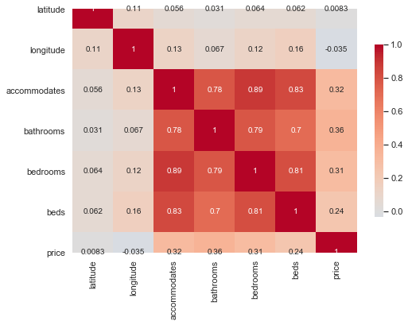

```python
# Computa la matriz de correlación
corr = dataFrameToPlot.corr()

# Crea una figura de tamaño 12, 12
f, ax = plt.subplots(figsize=(8, 8))

# Draw the heatmap with the mask and correct aspect ratio
sns.heatmap(corr, cmap='coolwarm', center=0, square=True, cbar_kws={"shrink": .5}, annot=True, ax=ax)
```

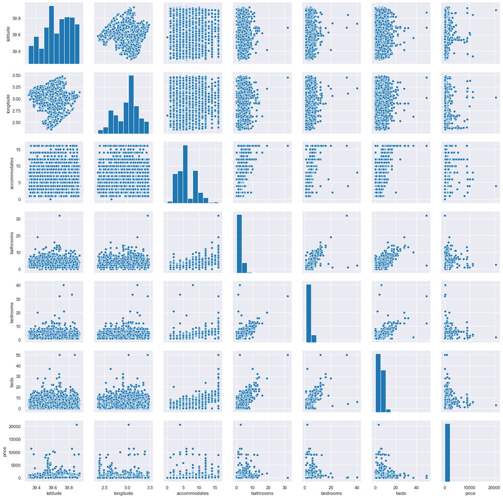

```python
sns.pairplot(dataFrameToPlot)
```

Dividimos entre variables dependientes e independientes

```python
X = df_transform[['latitude', 'longitude','room_type','accommodates','bathrooms', 'bedrooms','beds']]
y = df_transform['price']
```

## Definción de la estrategia a seguir

Vamos a transformar la variable categorica roomType a numerico para poder crear pipelines

```python
from sklearn.base import TransformerMixin
from sklearn.pipeline import Pipeline
### aux functions

class SelectColumns(TransformerMixin):
    def __init__(self, columns: list) -> pd.DataFrame:
        if not isinstance(columns, list):
            raise ValueError('Specify the columns into a list')
        self.columns = columns
    def fit(self, X, y=None): # we do not need to specify the target in the transformer. We leave it as optional arg for consistency
        return self
    def transform(self, X):
        return X[self.columns]

class DropColumns(TransformerMixin):
    def __init__(self, columns: list) -> pd.DataFrame:
        if not isinstance(columns, list):
            raise ValueError('Specify the columns into a list')
        self.columns = columns
    def fit(self, X, y=None):
        return self
    def transform(self, X):
        return X.drop(self.columns, axis=1)
```

Vamos a crear el step de modificar la variable categorica para poder tratarla como númerica y poder usarla como datos de entreno

```python
from sklearn.preprocessing import OneHotEncoder

select_col_step = ('select', SelectColumns(['room_type']))

one_hot_step = ('room_type_one_hot', OneHotEncoder(sparse=False))

cat_pipe_steps = [select_col_step, one_hot_step]

cat_pipe = Pipeline(cat_pipe_steps)
```

```python
df_transform_final = cat_pipe.fit_transform(df_transform)
```

```python
pd.DataFrame(df_transform_final)
```

|  | 0 | 1 | 2 | 3 |
| --- | --- | --- | --- | --- |
| 0 | 1.0 | 0.0 | 0.0 | 0.0 |
| 1 | 1.0 | 0.0 | 0.0 | 0.0 |
| 2 | 1.0 | 0.0 | 0.0 | 0.0 |
| 3 | 1.0 | 0.0 | 0.0 | 0.0 |
| 4 | 0.0 | 0.0 | 1.0 | 0.0 |
| ... | ... | ... | ... | ... |
| 17603 | 1.0 | 0.0 | 0.0 | 0.0 |
| 17604 | 1.0 | 0.0 | 0.0 | 0.0 |
| 17605 | 1.0 | 0.0 | 0.0 | 0.0 |
| 17606 | 0.0 | 0.0 | 1.0 | 0.0 |
| 17607 | 1.0 | 0.0 | 0.0 | 0.0 |

17608 rows × 4 columns

```python
cat_pipe['room_type_one_hot'].categories_
```

```
[array(['Entire home/apt', 'Hotel room', 'Private room', 'Shared room'],
       dtype=object)]
```

Creamos el step para poder hacer el escalado de los datos para poder modificar las entradas que sean NaN por valores medios, y metemos el sistema para no tener colinearidad

```python
from sklearn.preprocessing import MinMaxScaler
from sklearn.preprocessing import PolynomialFeatures
from sklearn.impute import SimpleImputer
from sklearn.preprocessing import StandardScaler
from sklearn.decomposition import PCA

drop_column_step = ('drop_column', DropColumns(['room_type']))

imputation_step = ('imputer', SimpleImputer(strategy='mean'))

scaler_step = ('scaler', MinMaxScaler())

pca_step = ('pca', PCA())

num_pipe_steps = [drop_column_step, imputation_step,  scaler_step, pca_step]

num_pipe = Pipeline(num_pipe_steps)
```

Creamos una full pipe que une las 2 anteriores

```python
from sklearn.pipeline import FeatureUnion
from sklearn.ensemble import RandomForestRegressor

transformer_list = [('num_pipe', num_pipe),('cat_pipe', cat_pipe)]

full_pipe = FeatureUnion(transformer_list=transformer_list)

full_pipe
```

```
FeatureUnion(n_jobs=None,
             transformer_list=[('num_pipe',
                                Pipeline(memory=None,
                                         steps=[('drop_column',
                                                 <__main__.DropColumns object at 0x000001A8D4B6C048>),
                                                ('imputer',
                                                 SimpleImputer(add_indicator=False,
                                                               copy=True,
                                                               fill_value=None,
                                                               missing_values=nan,
                                                               strategy='mean',
                                                               verbose=0)),
                                                ('scaler',
                                                 MinMaxScaler(copy=True,
                                                              feature_range=(0,
                                                                             1))),
                                                ('pca',
                                                 PCA(copy=True,
                                                     iterated...
                                                     whiten=False))],
                                         verbose=False)),
                               ('cat_pipe',
                                Pipeline(memory=None,
                                         steps=[('select',
                                                 <__main__.SelectColumns object at 0x000001A8D0606B88>),
                                                ('room_type_one_hot',
                                                 OneHotEncoder(categorical_features=None,
                                                               categories=None,
                                                               drop=None,
                                                               dtype=<class 'numpy.float64'>,
                                                               handle_unknown='error',
                                                               n_values=None,
                                                               sparse=False))],
                                         verbose=False))],
             transformer_weights=None, verbose=False)
```

## Pipe para resolver el problema de regression

Vamos a decidir el mejor modelo para hacer la regression teniamos 2 opciones de poder Una regression lineal normal o un arbol de decision. Se ha decidido usar un random forest regresor debido a las características de esto ya que mejoras a los arboles de decision normales.

Dividimos los datos en test y train con la función train_test_split

```python
from sklearn.model_selection import train_test_split

X_train, X_test, y_train, y_test = train_test_split(df_transform.drop('price', axis=1), df_transform.price, test_size=0.2)
```

```python
from sklearn.model_selection import GridSearchCV

regressor_step = ('model', RandomForestRegressor())

full_pipe_step = ('def_pipeline', full_pipe)
pipe_steps = [full_pipe_step, regressor_step]
pipe = Pipeline(pipe_steps)

param_grid = {'def_pipeline__num_pipe__imputer__strategy': ['mean', 'median', 'most_frequent', 'constant'],
              'model__max_depth': [3, 5, 8, 10, 12 ,15, 17, 20, 25, 30],
              'model__min_samples_leaf': [2, 5, 8, 10, 15, 17, 20, 25, 30]}

## usamos el pipe como estimador en el gridsearch
rg_gs = GridSearchCV(pipe, cv=5, n_jobs=-1, param_grid=param_grid, verbose=1)

rg_gs.fit(X_train, y_train)

print('Best params: ', rg_gs.best_params_)
print('Best score: ', rg_gs.best_score_)

y_predict = rg_gs.predict(X_test)
```

```
Fitting 5 folds for each of 360 candidates, totalling 1800 fits
```

```
[Parallel(n_jobs=-1)]: Using backend LokyBackend with 4 concurrent workers.
[Parallel(n_jobs=-1)]: Done  42 tasks      | elapsed:    9.3s
[Parallel(n_jobs=-1)]: Done 192 tasks      | elapsed:   41.9s
[Parallel(n_jobs=-1)]: Done 442 tasks      | elapsed:  1.9min
[Parallel(n_jobs=-1)]: Done 792 tasks      | elapsed:  3.3min
[Parallel(n_jobs=-1)]: Done 1242 tasks      | elapsed:  5.3min
[Parallel(n_jobs=-1)]: Done 1792 tasks      | elapsed:  7.7min
[Parallel(n_jobs=-1)]: Done 1800 out of 1800 | elapsed:  7.7min finished
```

```
Best params:  {'def_pipeline__num_pipe__imputer__strategy': 'mean', 'model__max_depth': 17, 'model__min_samples_leaf': 10}
Best score:  0.21799793871683396
```

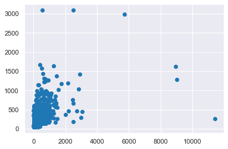

```python
plt.scatter(y_test, y_predict)
```

En esta gráfica podemos ver el resultado de las predicciones donde podemos ver que las predicciones no són buenas, sobretodo por los outliers aunque el error igualmente hay una gran cantidad de errores en las predicciones. Estos errores pueden deberse a muchos factores. Primero podría ser que los datos seleccionados al principio no eran los correctos por ejemplo los ammenities quizas influencian en el resultado final si hubieran sido elegidas en el model. También decir que muchos de los datos que se visualizan en la gràfica estan muy concentrados los valores que aciertan mejor. Por eso se tendrian que analizar las características de las casas para poder modificar los inputs de la regression.

```python
from sklearn.metrics import mean_absolute_error, mean_squared_error, r2_score

def MAPE(y_true, y_pred):
    """
    Returns de MAPE of two vectors.
    """
    return np.mean(np.abs((y_true - y_pred)/y_true))

print("MAE:", mean_absolute_error(y_test, y_predict))
print("MSE:", mean_squared_error(y_test, y_predict))
print("MAPE:", MAPE(y_test, y_predict))
print("r2_score:", r2_score(y_test, y_predict))
```

[output not shown]

Finalmente podemos ver que las metricas nos indican que hay un error muy grande. Aunque a primera vista se puede pensar que el error medio es solo de aproximadamente de 110€ esto puede ser una cifra que podría afectar mucho a las ventas de airbnb. Lo que podemos ver de las metricas es que el modelo da mucha importancia a valores grande cosa que el tener casa de valor alto y predicciones con error grande, por tant se tendria que estudiar estos valores en concreto. Por último el r2 indica que las predicciones del modelo no són buenas y se deberia revisar si la estrategia usada es incorrecta, porque o si el problema viene de los datos que se han utilitzado como input y porque funciona así.